# BCB420 Assignment 1

Dataset Selection and Initial Processing

Maryam Hasanzadehkiabi

2023-03-07

# 1. Dataset selection

## Insert and running required packages

[@xie2018r] [@allaire2023rmarkdown] [@xie2020r] [@Zhu2021] [@Müller2023] [@Wickham2022] [@Davis2007] [@Morgan2022] [@zhu2008geometadb] [@durinck2009mapping] [@durinck2005biomart] [@drost2017biomartr] [@loraine2015analysis] [@robinson2010edger] [@Wickham2022dev] [@Dervieux2022] [@Xie2023kni] [@Xie2015kni] [@Stodden2014]

```r
if (!requireNamespace("rmarkdown", quietly = TRUE))
    +     install.packages("rmarkdown")
if (!requireNamespace("knitr", quietly = TRUE))
    +     install.packages("knitr")
if (!requireNamespace("pandoc", quietly = TRUE))
    +     install.packages("pandoc")
if (!requireNamespace("devtools", quietly = TRUE))
    +     install.packages("devtools")
if (!requireNamespace("BiocManager", quietly = TRUE))
    +     install.packages("BiocManager")
if (!requireNamespace("edgeR", quietly = TRUE))
    BiocManager::install("edgeR")
if (!requireNamespace("biomaRt", quietly = TRUE))
    BiocManager::install("biomaRt")
if (!requireNamespace("GEOmetadb", quietly = TRUE))
    BiocManager::install("GEOmetadb")
if (!requireNamespace("GEOquery", quietly = TRUE))
    +     install.packages("GEOquery")
if (!requireNamespace("DBI", quietly = TRUE))
    +     install.packages("DBI")
if (!requireNamespace("RSQLite", quietly = TRUE))
    +     install.packages("RSQLite")
if(!requireNamespace("kableExtra", quietly=TRUE))
    install.packages("kableExtra")
library(devtools)
library(rmarkdown)
library(knitr)
library(pandoc)
library(BiocManager)
library(GEOmetadb)
library(GEOquery)
library(DBI)
library(RSQLite)
library(edgeR)
library(biomaRt)
library(kableExtra)
```

## Dataset Selection Criteria

```r
sql <- paste("SELECT DISTINCT gse.title,gse.gse, gpl.title,",
             " gse.submission_date,",
             " gse.supplementary_file",
             "FROM",
             "  gse JOIN gse_gpl ON gse_gpl.gse=gse.gse",
             "  JOIN gpl ON gse_gpl.gpl=gpl.gpl",
             "WHERE",
             "  gse.submission_date > '2013-01-01' AND",
             "  gse.title LIKE '%colon cancer%' AND",
             "  gpl.organism LIKE '%Homo sapiens%' AND",
             "  gpl.technology LIKE '%high-throughput sequencing%' ",
             "  ORDER BY gse.submission_date DESC",sep=" ")
```

Selecting series with counts data

```r
if(!file.exists('GEOmetadb.sqlite')) getSQLiteFile()
con <- dbConnect(SQLite(),'GEOmetadb.sqlite')
rs <- dbGetQuery(con,sql)
counts_files <- rs$supplementary_file[grep(rs$supplementary_file,
                              pattern = "count|cnt",ignore.case = TRUE)]

series_of_interest <- rs$gse[grep(rs$supplementary_file,
                              pattern = "count|cnt",ignore.case = TRUE)]

shortened_filenames <- unlist(lapply(counts_files,
             FUN = function(x){x <- unlist(strsplit(x,";")) ;
              x <- x[grep(x,pattern= "count|cnt",ignore.case = TRUE)];
               tail(unlist(strsplit(x,"/")),n=1)}))
shortened_filenames[1:10]
```

```
##  [1] "GSE161349_Counts_noadj_exons_condense.txt.gz"
##  [2] "GSE152430_raw_gene_count_matrix.txt.gz"
##  [3] "GSE147111_ReadCounts.csv.gz"
##  [4] "GSE146009_Caucasian_RawCounts.txt.gz"
##  [5] "GSE142314_countsMatrix_normalized.csv.gz"
##  [6] "GSE125282_CC36_and_CC14_Raw_counts_all.xlsx"
##  [7] "GSE118504_SSAP_NormalizedReadCounts.xls.gz"
##  [8] "GSE98922_counts.txt.gz"
##  [9] "GSE92432_gene_count_matrix.csv.gz"
## [10] "GSE82236_miRNA_counts.txt.gz"
```

The first 10 outputs of the interested series show studies focused on colorectal genomics, and hold the selection criteria. After quick reviewing, I chose GSE98922 [@schmidt2018targeting].

## Details of the Selected Series

Number of entities

```r
gse <- getGEO("GSE98922",GSEMatrix=FALSE)
```

```
## Reading file....
```

```
## Parsing....
```

[output not shown]

```
## GPL18460 (1 of 11 entities)
```

```
## GSM2627682 (2 of 11 entities)
```

```
## GSM2627683 (3 of 11 entities)
```

```
## GSM2627684 (4 of 11 entities)
```

```
## GSM2627685 (5 of 11 entities)
```

```
## GSM2627686 (6 of 11 entities)
```

```
## GSM2627687 (7 of 11 entities)
```

```
## GSM2627688 (8 of 11 entities)
```

```
## GSM2627689 (9 of 11 entities)
```

```
## GSM2627690 (10 of 11 entities)
```

Data owner contact information

```r
kable(data.frame(head(Meta(gse))), format = "pipe")
```

| contact_address | contact_city | contact_country | contact_department | contact_email | contact_institute |
| --- | --- | --- | --- | --- | --- |
| Feodor-Lynen-Str. 25 | Munich | Germany | Gene Center | krebs-st@lmb.uni-muenchen.de | Ludwig-Maximilian University |

Name and number of the samples

```r
names(GSMList(gse))
```

```
## [1] "GSM2627682" "GSM2627683" "GSM2627684" "GSM2627685" "GSM2627686"
## [6] "GSM2627687" "GSM2627688" "GSM2627689" "GSM2627690"
```

Series includes 9 samples.

More information about the series

```r
show(getGEO("GSE98922",GSEMatrix=TRUE))
```

```
## Found 1 file(s)
```

```
## GSE98922_series_matrix.txt.gz
```

```
## $GSE98922_series_matrix.txt.gz
## ExpressionSet (storageMode: lockedEnvironment)
## assayData: 0 features, 9 samples
##   element names: exprs
## protocolData: none
## phenoData
##   sampleNames: GSM2627682 GSM2627683 ... GSM2627690 (9 total)
##   varLabels: title geo_accession ... tissue:ch1 (46 total)
##   varMetadata: labelDescription
## featureData: none
## experimentData: use 'experimentData(object)'
##   pubMedIds: 29769248
## Annotation: GPL18460
```

Samples classification

```r
data.frame(getGEO("GSE98922",GSEMatrix=TRUE)[[1]])[,]
```

```
## Found 1 file(s)
```

```
## GSE98922_series_matrix.txt.gz
```

```
## Using locally cached version: /var/folders/_4/njpp9gxn5jbg5_44_7hgx14h0000gn/T//RtmpA8pHt1/GSE98922_series_matrix.txt.gz
```

```
## Using locally cached version of GPL18460 found here:
## /var/folders/_4/njpp9gxn5jbg5_44_7hgx14h0000gn/T//RtmpA8pHt1/GPL18460.soft.gz
```

[output not shown]

[output cut: 175 more lines]

```
## GSM2627686 SRA: https://www.ncbi.nlm.nih.gov/sra?term=SRX2823499
## GSM2627687 SRA: https://www.ncbi.nlm.nih.gov/sra?term=SRX2823500
## GSM2627688 SRA: https://www.ncbi.nlm.nih.gov/sra?term=SRX2823501
## GSM2627689 SRA: https://www.ncbi.nlm.nih.gov/sra?term=SRX2823502
## GSM2627690 SRA: https://www.ncbi.nlm.nih.gov/sra?term=SRX2823503
##            supplementary_file_1 agent.ch1 tissue.ch1
## GSM2627682                 NONE   vehicle  xenograft
## GSM2627683                 NONE   vehicle  xenograft
## GSM2627684                 NONE   vehicle  xenograft
## GSM2627685                 NONE       AZD  xenograft
## GSM2627686                 NONE       AZD  xenograft
## GSM2627687                 NONE       AZD  xenograft
## GSM2627688                 NONE       DBZ  xenograft
## GSM2627689                 NONE       DBZ  xenograft
## GSM2627690                 NONE       DBZ  xenograft
```

There are 3 groups in the study, including 3 vehicle_treated, 3 AZD_treated, and 3 DBZ_treated; total 9 samples.

## Platform details

```r
current_gpl <- names(GPLList(gse))[1]
current_gpl_info <- Meta(getGEO(current_gpl))
```

```
## Using locally cached version of GPL18460 found here:
## /var/folders/_4/njpp9gxn5jbg5_44_7hgx14h0000gn/T//RtmpA8pHt1/GPL18460.soft.gz
```

**Platform accession number:**

```r
current_gpl_info$geo_accession
```

```
## [1] "GPL18460"
```

**Platform title:**

```r
current_gpl_info$title
```

```
## [1] "Illumina HiSeq 1500 (Homo sapiens)"
```

**Submission date:**

```r
current_gpl_info$submission_date
```

```
## [1] "Mar 24 2014"
```

**Last update date:**

```r
current_gpl_info$last_update_date
```

```
## [1] "Oct 02 2018"
```

**Organisms:**

```r
current_gpl_info$organism
```

```
## [1] "Homo sapiens"
```

**Technology:**

```r
current_gpl_info$technology
```

```
## [1] "high-throughput sequencing"
```

**Number of GEO datasets that use this technology:*

```r
length(current_gpl_info$series_id)
```

```
## [1] 330
```

**Number of GEO samples that use this technology:**

```r
length(current_gpl_info$sample_id)
```

```
## [1] 6413
```

# 2. Data expression

Supplementary files

```r
supp_files = getGEOSuppFiles('GSE98922')
file_names = rownames(supp_files)
print(file_names)
```

```
## [1] "/Users/maryamhasanzadehkiabi/Desktop/BCB420/Maryam_Hasanzadehkiabi/Assignmentnew1+2/GSE98922/GSE98922_counts.txt.gz"
## [2] "/Users/maryamhasanzadehkiabi/Desktop/BCB420/Maryam_Hasanzadehkiabi/Assignmentnew1+2/GSE98922/GSE98922_rlog_transformed.txt.gz"
```

There are two supplementary files provided for this dataset, one includes counts and the other one contains rlog_transformed [@schmidt2018targeting]. Researchers studied NOTCH, MAPK, and WNT pathways signaling effect on a total 328 adenocarcinoma. Tumor cells located at the tumor edge with MAPK and WNT high activity showed epithelial-mesenchymal transition (EMT) phenotype, while tumor cells located at the tumor center showed more epithelial phenotype [@schmidt2018targeting]. Counts file is being used for further analysis.

```r
genes_expression = read.delim(file_names[1],header=TRUE,
          check.names = FALSE)
```

In the following section, number of the genes and name of the variables included in the dataset are presented; since the first column includes gene names without column name, “hgnc_symbol” is assigned to the first column name.

```r
dim(genes_expression)
```

```
## [1] 23373    10
```

```r
colnames(genes_expression)[1] <- "hgnc_symbol"
colnames(genes_expression)
```

```
##  [1] "hgnc_symbol" "control1"    "control2"    "control3"    "TreatmentA1"
##  [6] "TreatmentA2" "TreatmentA3" "TreatmentD1" "TreatmentD2" "TreatmentD3"
```

Samples category

Considering the treatment agent, there are 3 groups including vehicle-treated tumors (controls), MEK inhibitor-treated (selumetinib (AZD)), and γ-secretase inhibitor-treated (dibenzazepine (DBZ)); each group contains 3 replicates.

```r
dataSamples <- data.frame(lapply(colnames(genes_expression)[2:10],
FUN=function(x){substr(x, 1, nchar(x)-1)}))
colnames(dataSamples) <- colnames(genes_expression)[2:10]
dataSamples <- data.frame(t(dataSamples))
dataSamples[dataSamples == "control"] <- "Vehicle"
dataSamples[dataSamples == "TreatmentA"] <- "AZD"
dataSamples[dataSamples == "TreatmentD"] <- "DBZ"
colnames(dataSamples) <- "Agent"
```

# 3. Genes cleaning and filtering

## Duplication

Checking potential duplication. If the logical output returns any “TRUE” value, there does exist duplication. Otherwise the set contains unique genes.

```r
summary(duplicated(genes_expression$hgnc_symbol))
```

```
##    Mode   FALSE
## logical   23373
```

```r
summary(is.na(genes_expression$hgnc_symbol))
```

```
##    Mode   FALSE
## logical   23373
```

Since there is no “TRUE” value in the output, dataset dose not include any duplicate or missing value genes.

## Outliers

```r
cpms = cpm(genes_expression[,2:10])
rownames(cpms) <- genes_expression$hgnc_symbol
keep = rowSums(cpms > 2) >=3
genes_filtered = genes_expression[keep,]
```

## Data distribution before normalization

Boxplot

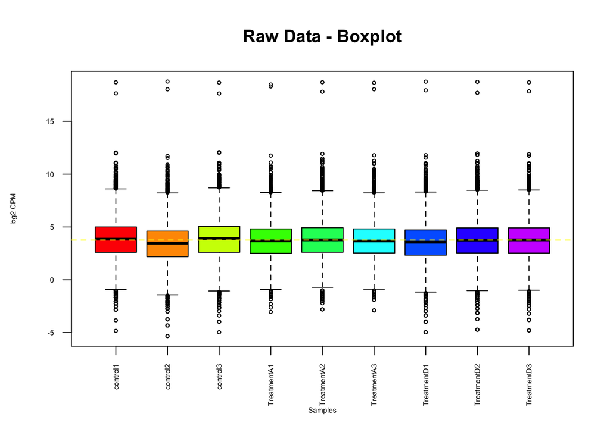

```r
data2plot <- log2(cpm(genes_filtered[,2:10]))
colnames(data2plot) <- colnames(genes_filtered)[2:10]
boxplot(data2plot, xlab = "Samples", ylab = "log2 CPM",
las = 2, cex = 0.5, cex.lab = 0.5,
cex.axis = 0.5, main = "Raw Data - Boxplot", col=rainbow(10))
abline(h = median(apply(data2plot, 2, median)),
col = "yellow", lwd = 1.2, lty = "dashed")
```

Outliers with negative infinity are rnot drawn in plot.

Density plot

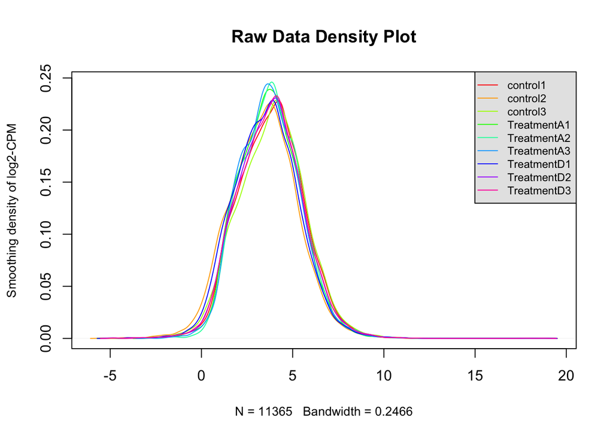

```r
counts_density <- apply(log2(cpm(genes_filtered[,2:10])),
2, density)
xlim <- 0; ylim <- 0
for (i in 1:length(counts_density)) {
xlim <- range(c(xlim, counts_density[[i]]$x));
ylim <- range(c(ylim, counts_density[[i]]$y))
}
cols <- rainbow(length(counts_density))
ltys <- rep(1, length(counts_density))
plot(counts_density[[1]], xlim=xlim, ylim=ylim, type="n",
ylab="Smoothing density of log2-CPM",
main="Raw Data Density Plot", cex.lab = 0.85)
for (i in 1:length(counts_density))
lines(counts_density[[i]], col=cols[i], lty=ltys[i])
legend("topright", colnames(genes_expression[2:10]),
col=cols, lty=ltys, cex=0.75,
border ="blue", text.col = "black",
merge = TRUE, bg = "gray90")
```

It seems that data follows a normal distribution pattern.

MA plot

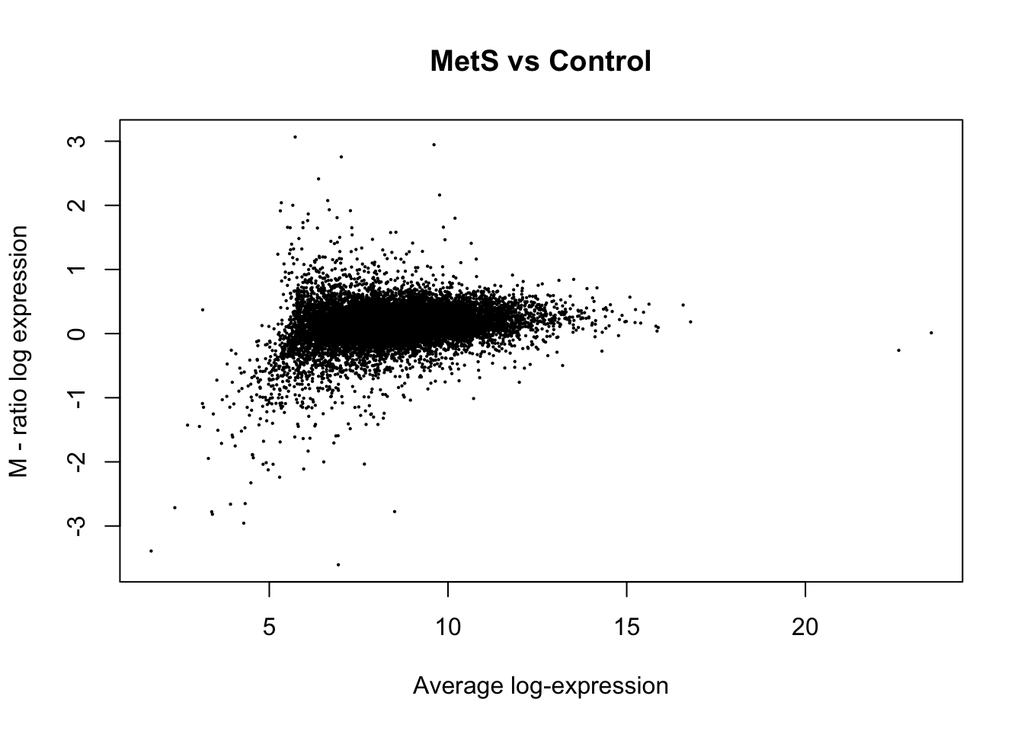

```r
plotMA(log2(genes_filtered[,c(2:4,5:7,8:10)]), ylab="M - ratio log expression",
main="MetS vs Control")
```

# 4. Mapping

To perform mapping, hgnc_symbol is selected

```r
ensembl <- useMart("ensembl")
ensembl = useDataset("hsapiens_gene_ensembl",mart=ensembl)
gene_mapped <- getBM(attributes = c("ensembl_gene_id","hgnc_symbol"),
filters = c("hgnc_symbol"),
values = genes_filtered$hgnc_symbol,
mart = ensembl)
```

```r
length(which(rownames(cpms) %in%
gene_mapped$hgnc_symbol))
```

```
## [1] 10089
```

Total number of genes with measurements

```r
nrow(cpms)
```

```
## [1] 23373
```

Number of genes that could not be mapped

```r
nrow(cpms) - length(which(rownames(cpms) %in%
gene_mapped$hgnc_symbol))
```

```
## [1] 13284
```

```r
cpms_annot <- merge(gene_mapped,cpms,
by.x = 2, by.y = 0, all.y=TRUE)
kable(cpms_annot[1:6,c(1,2,3,8)],format = "html")
```

| hgnc_symbol | ensembl_gene_id | control1 | TreatmentA3 |
| --- | --- | --- | --- |
| __alignment_not_unique | NA | 4.225227e+05 | 4.110355e+05 |
| __ambiguous | NA | 4.207742e+03 | 3.538891e+03 |
| __no_feature | NA | 2.043480e+05 | 2.668490e+05 |
| __not_aligned | NA | 0.000000e+00 | 0.000000e+00 |
| __too_low_aQual | NA | 0.000000e+00 | 0.000000e+00 |
| 1/2-SBSRNA4 | NA | 8.727438e-01 | 9.835716e-01 |

- Another method to check ensembl ID missing genes.

```r
length(ensembl_id_missing_gene <- cpms_annot$ensembl_gene_id[
which(is.na(cpms_annot$ensembl_gene_id))])
```

```
## [1] 13284
```

Presenting the first 10 ensembl IDs that do not match with HUGO

```r
kable(cpms_annot[which(is.na(cpms_annot$ensembl_gene_id)),1:3], format = "pipe")[1:12]
```

```
##  [1] "|      |hgnc_symbol            |ensembl_gene_id |     control1|"
##  [2] "|:-----|:----------------------|:---------------|------------:|"
##  [3] "|1     |__alignment_not_unique |NA              | 4.225227e+05|"
##  [4] "|2     |__ambiguous            |NA              | 4.207742e+03|"
##  [5] "|3     |__no_feature           |NA              | 2.043480e+05|"
##  [6] "|4     |__not_aligned          |NA              | 0.000000e+00|"
##  [7] "|5     |__too_low_aQual        |NA              | 0.000000e+00|"
##  [8] "|6     |1/2-SBSRNA4            |NA              | 8.727438e-01|"
##  [9] "|7     |A1BG                   |NA              | 0.000000e+00|"
## [10] "|8     |A1BG-AS1               |NA              | 0.000000e+00|"
## [11] "|10    |A2LD1                  |NA              | 2.653141e+00|"
## [12] "|11    |A2M                    |NA              | 4.538268e-01|"
```

# 5. Normalization

Checking potential duplication

```r
summary(duplicated(gene_mapped$ensembl_gene_id))
```

```
##    Mode   FALSE
## logical   11166
```

```r
summary(duplicated(gene_mapped$hgnc_symbol))
```

```
##    Mode   FALSE    TRUE
## logical   10089    1077
```

Removing duplication, and creating appropriate file to perform normalization analysis

```r
gene_mapped_unique <- unique(gene_mapped$hgnc_symbol)
gene_mapped_unique <- data.frame(gene_mapped_unique)
rownames(gene_mapped_unique) <- gene_mapped_unique$gene_mapped_unique
gene_mapped_unique_counts = genes_expression[which(rownames(gene_mapped_unique)%in% genes_expression$hgnc_symbol),]
```

MA Plot

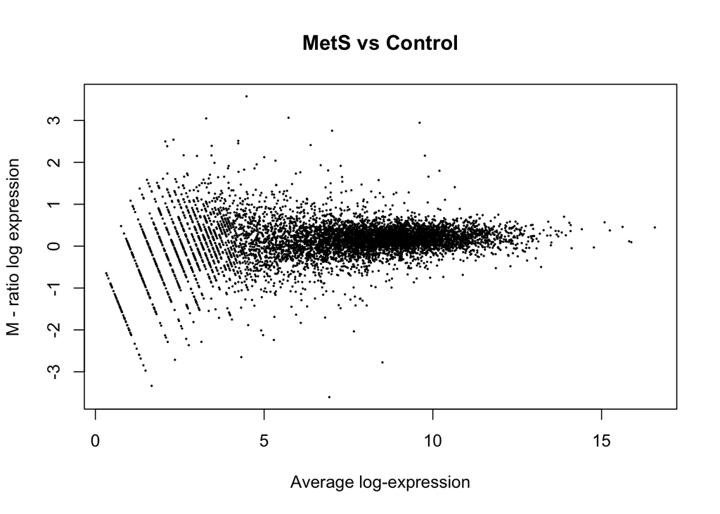

```r
plotMA(log2(gene_mapped_unique_counts[,c(2:4,5:7,8:10)]), ylab="M - ratio log expression",main="MetS vs Control")
```

Trimmed Mean of M-values (TMM)

```r
filtered_data_matrix <- as.matrix(gene_mapped_unique_counts[,2:10])
rownames(filtered_data_matrix) <- gene_mapped_unique_counts$hgnc_symbol
d = DGEList(counts=filtered_data_matrix, group = dataSamples$Agent)
```

Normalization factors

```r
d = calcNormFactors(d)
d$samples[1:9,]
```

```
##               group lib.size norm.factors
## control1    Vehicle  4663352    0.9858543
## control2    Vehicle  5016253    0.9742314
## control3    Vehicle  5212349    0.9673308
## TreatmentA1     AZD  3424733    1.0419864
## TreatmentA2     AZD  4326418    1.0090235
## TreatmentA3     AZD  3191639    1.0578584
## TreatmentD1     DBZ  4195323    0.9800913
## TreatmentD2     DBZ  4120687    0.9855747
## TreatmentD3     DBZ  4209774    1.0018512
```

```r
#kable(d$samples[,], format = "html") %>% row_spec(c(1,8,9,10), background = "yellow")
```

```r
normalized_counts <- cpm(d)
```

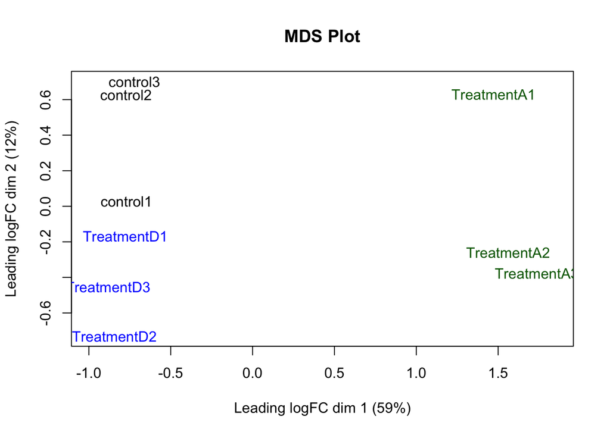

```r
plotMDS(d, labels=rownames(dataSamples), col = c("darkgreen","blue")[factor(dataSamples$Agent)], main="MDS Plot")
```

```r
model_design <- model.matrix(~dataSamples$Agent)
```

```r
d <- estimateDisp(d, model_design)
```

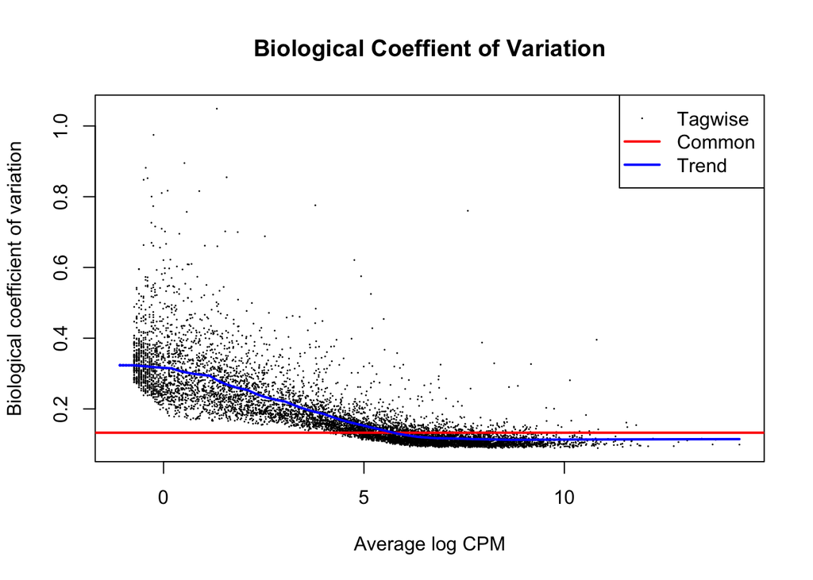

```r
plotBCV(d,col.tagwise = "black",col.common = "red",col.trend = "blue", main="Biological Coeffient of Variation")
```